# Coursework Report 202091

*N* removed NAs: 5

*N* removed <18: 28

**Correct typo age:** 20

*N* total clean: 135

| Group | *N* | *M*<sub>age</sub> | % green |
| --- | --- | --- | --- |
| Control | 68 | 20.50 | 32.84 |
| Experim | 67 | 20.55 | 53.23 |

| Gender | *N* | *M*<sub>age</sub> | % green |
| --- | --- | --- | --- |
| Female | 69 | 20.52 | 44.93 |
| Male | 48 | 20.48 | 38.89 |
| Other | 18 | 20.67 | 46.30 |

**Main analysis results**

**car:**  
χ<sup>2</sup>(1) = 3.95, *p* = .047

**cleaner:**  
χ<sup>2</sup>(1) = 2.68, *p* = .102

**dishwasher:**  
χ<sup>2</sup>(1) = 9.26, *p* = .002

[interactive chart not shown]

[figure not shown]

[interactive chart not shown]

# Coursework Report 202091

Analysing Data, Spring 2020

# Methods

## Participants

Table 1 *Descriptive statistics by Gender*

| Gender | *N* | % | *M*<sub>age</sub> | *SD*<sub>age</sub> |
| --- | --- | --- | --- | --- |
| female | 168 | 50.0 | 21.07 | 1.88 |
| male | 126 | 37.5 | 20.83 | 1.68 |
| other | 42 | 12.5 | 21.43 | 1.74 |

## Design

The conceptual hypothesis argues that more people will purchase more green products in comparison to their luxurious counterparts, due to the altruistic benefits brought by the notion that it positively serves the environment. This is despite the all green and non-green products being of the same value but lower in quality. The study follows a between-subjects design, where each participant is only exposed to one of the conditions. The independent variable was the motive conditions of either status or control. Within the experimental condition, the status motives were evoked through participants reading a short story. The objective of the story purposefully produces a desire for social status and prestige, but does not necessarily promote the idea of “cooperation, helping, self-sacrifice, or pro-environmental behaviour” (Griskevicius et al, 2010). In the control condition, participants read a similar story which is purposely designed to elicit the same level of affect as the status story. However, it does not present the notion of a sense of status increase.

Participants are then told that to shop for three products; a car, a household cleaner, and a dishwasher. These products were chosen as they are available in both a pro-environmental form and a conventional form, and so the participants are presented with a choice for each of the products. Of each item, both versions products are priced equally. Prior to this, a questionnaire established that people who purchased any of the three ‘green’ products were perceived to be higher on the social scale. Therefore, the dependent variable was whether participants would choose either the green or non-green product.

# Results

A simple bar graph was created for each type of product with the story condition as the predictor and the frequency of each product choice as the outcome. This determined whether there was a relationship between motivational desires and the type of product chosen. The continuing trend within all three products shows that there is a positive correlation in choosing the green product choice within the experimental condition than the control condition.

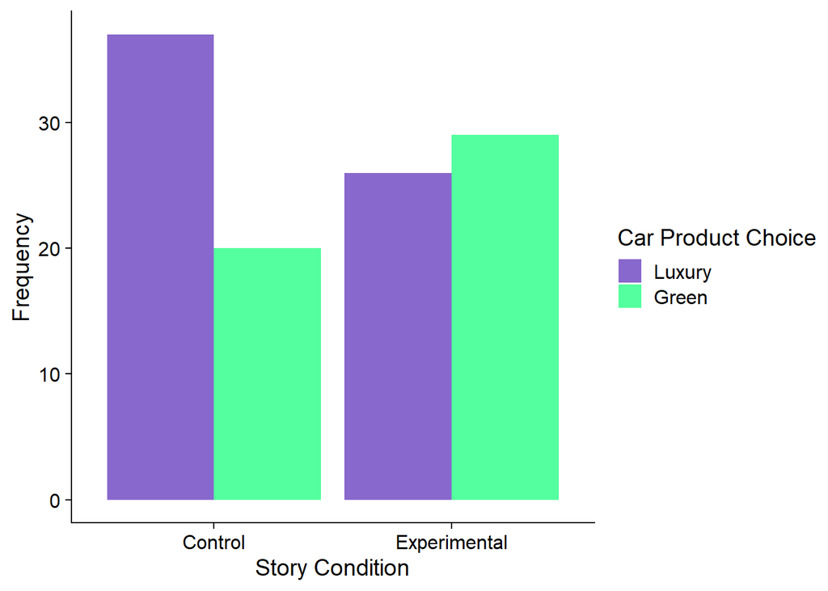

#### **Figure 1. A bar graph showing the frequency of car product choices by story condition.**

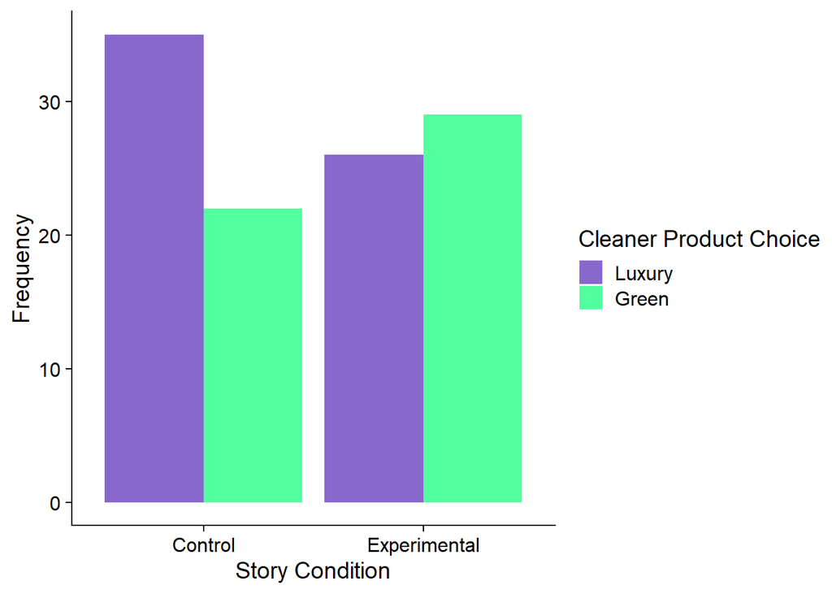

#### **Figure 2. A bar graph showing the frequency of cleaner product choices by story condition.**

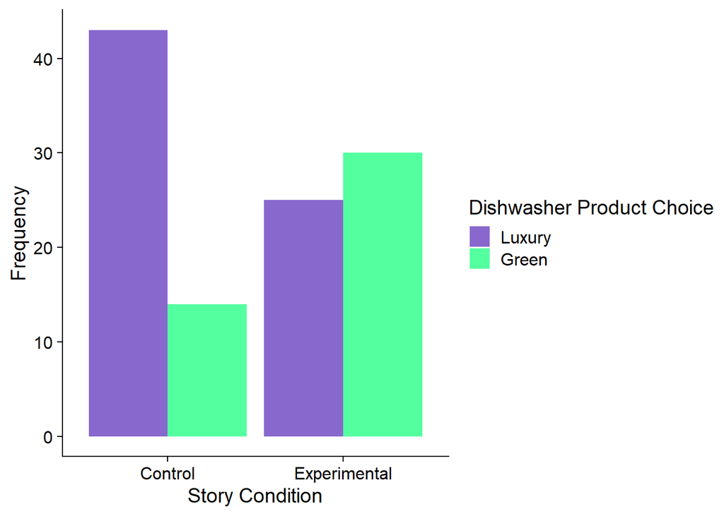

#### **Figure 3. A bar graph showing the frequency of dishwasher product choice by story condition.**

Figure 3 demonstrates a relationship between the frequency of the dishwasher product in relation to the control and experimental condition. The main trend in the graph exemplifies a significant difference in product choice as the frequency of the luxury product is 43, whereas the green product is only at a frequency of 14 within the control condition. On the contrary, during the experimental condition the frequency of green products (30) in comparison to luxury products chosen (25) is not as vast. However, it still shows the continuing trend replicated within the car and cleaner products. Therefore, the dishwasher product choice also supports the study’s hypothesis.